# ESM 204 Homework 4: Calculating SCC and policy choice under uncertianty

Anna Zauner

May 27th, 2022

## Introduction:

In this report, estimates of the future impacts of climate change are used to inform an update to the SCC.

The data in this analysis comes from two datasets, “damages.csv” and “warming.csv”. Data on damages includes total damages from climate change with different levels of warming, in degrees C. Warming data includes estimates of a baseline of future climate trajectory, in degrees C, until 2100. A second trajectory is included which adds a one-time pulse of CO2 into the atmosphere today. This pulse is equal to annual global emissions.

## Question 1

Estimate a quadratic damage function relating the dollar value of damages to the change in global mean temperature. Estimate a model with a zero intercept because damages by construction must equal zero when there is no climate change. Plot your estimated damage function, overlaid with a scatterplot of the underlying data.

```
##
## Call:
## lm(formula = damages ~ 0 + warming + damage_warming, data = damage)
##
## Coefficients:
##        warming  damage_warming
##     -1.060e+12       1.941e+13
```

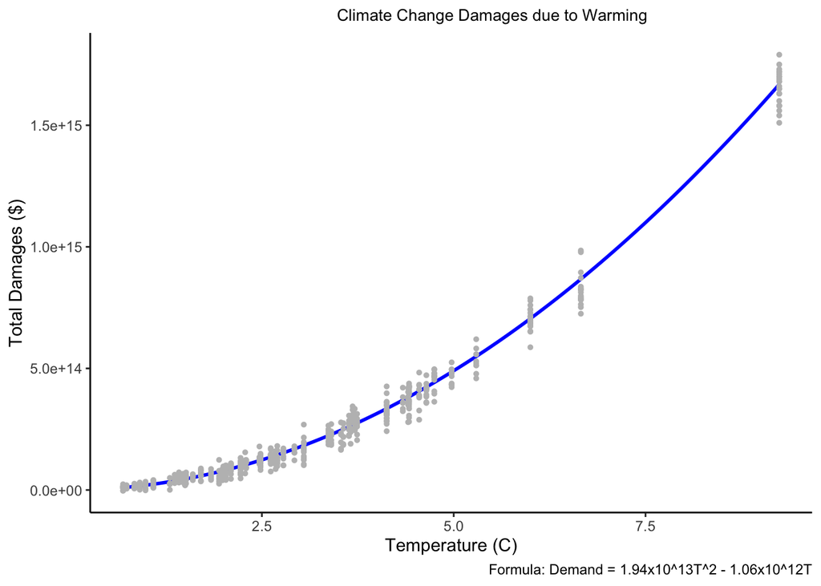

## Question 2

Use warming.csv and your estimated damage function to predict damages in each year under the baseline climate and the pulse scenario. Make four plots: (1) damages over time without the pulse, (2) damages over time with the pulse, (3) the difference in damages over time that arises from the pulse, and (4) the difference in damages over time from the pulse per ton of CO2 (you can assume that each ton of the pulse causes the same amount of damage).

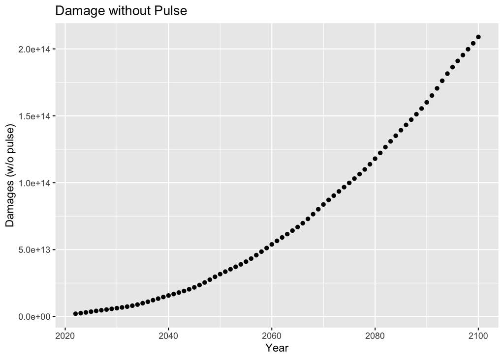

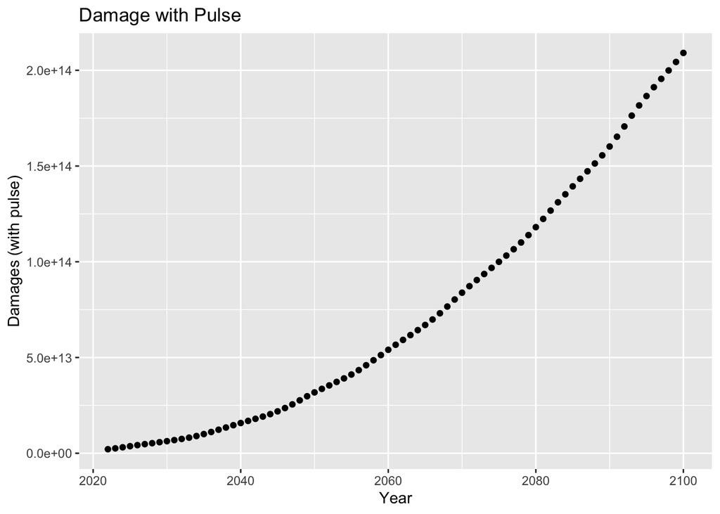

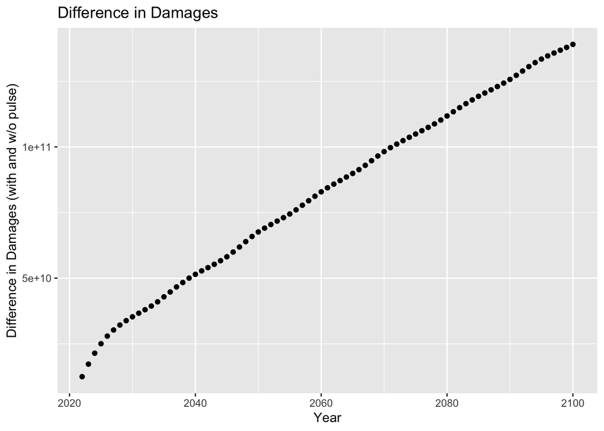

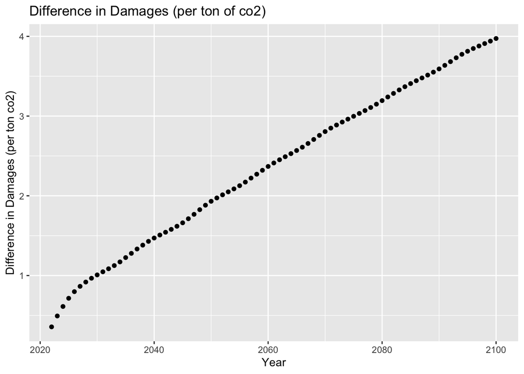

## Question 3

The SCC is the present discounted value of the stream of future damages caused by one additional ton of CO2. The Obama Administration used a discount rate of 3% to discount damages. Recently, New York State used a discount rate of 2%. Calculate and make a plot of the SCC (y-axis) against the discount rate (x-axis) for a reasonable range of discount rates. Explain the intuition for how the discount rate affects the SCC.

```
## # A tibble: 79 × 13
##     year difference_per_ton t_future present_value_01 present_value_02
##    <dbl>              <dbl>    <dbl>            <dbl>            <dbl>
##  1  2022              0.356        0            0.356            0.356
##  2  2023              0.493        1            0.488            0.483
##  3  2024              0.612        2            0.600            0.588
##  4  2025              0.715        3            0.694            0.674
##  5  2026              0.798        4            0.767            0.737
##  6  2027              0.864        5            0.823            0.783
##  7  2028              0.918        6            0.865            0.815
##  8  2029              0.966        7            0.901            0.841
##  9  2030              1.01         8            0.931            0.860
## 10  2031              1.05         9            0.957            0.876
## # … with 69 more rows, and 8 more variables: present_value_03 <dbl>,
## #   present_value_04 <dbl>, present_value_05 <dbl>, present_value_06 <dbl>,
## #   present_value_07 <dbl>, present_value_08 <dbl>, present_value_09 <dbl>,
## #   present_value_1 <dbl>
```

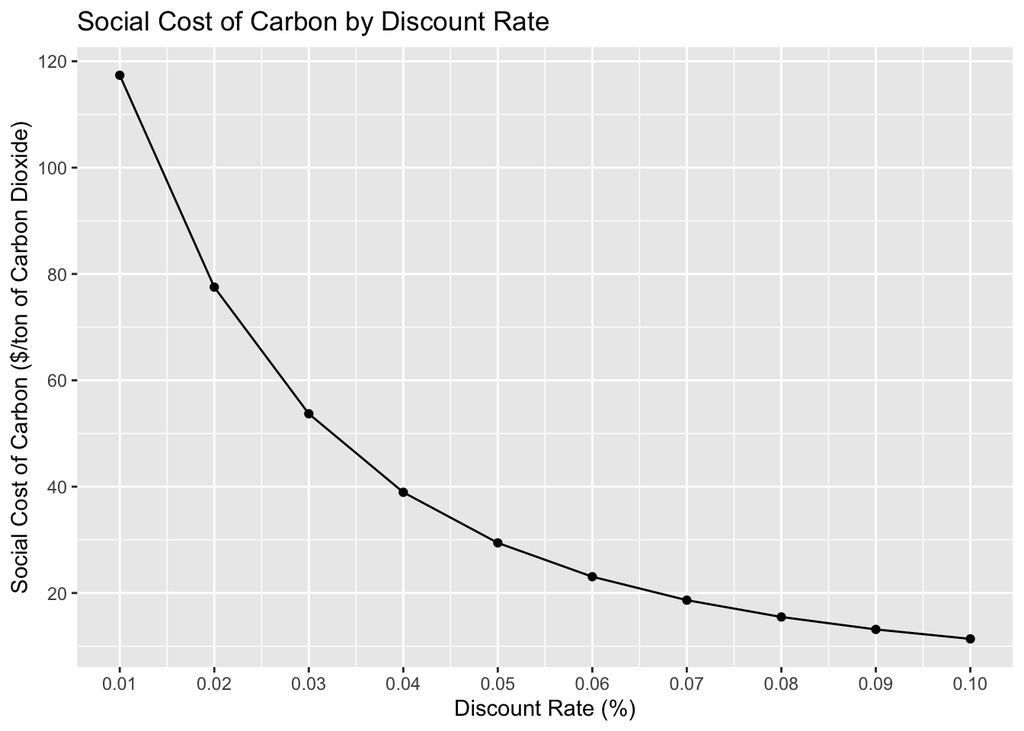

Higher discount rates result in a lower SCC; if future climate damages are discounted at a high rate, we would be placing less value on avoiding those damages today.

## Question 4

The National Academies of Sciences, Engineering, and Medicine advised the government in a 2017 report to use the Ramsey Rule when discounting within the SCC calculation: r = ρ + ηg Using ρ = 0.001, η = 2, and g = 0.01, what is the SCC? Locate this point on your graph from above

```
## [1] 2.1
```

```
## [1] 74.57039
```

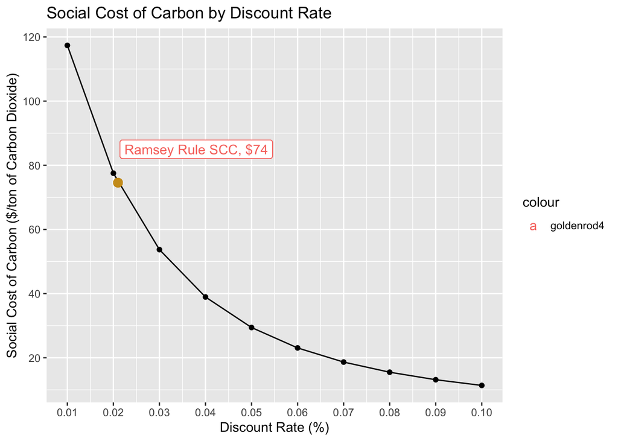

## Question 5

Now suppose there are two possible climate policies that can be pursued. Policy A is business as usual and Policy B is to take immediate and strong action on climate change.

Use these facts: - If you undertake Policy A there are two possible outcomes. Either warming will occur as in the “baseline” (i.e. “no-pulse”) dataset above (this happens with probability 0.5) or warming each year will be 1.5 times that in the “baseline” dataset (with probability 0.5).

- Under Policy B, warming will continue until 2050 as in the “baseline” dataset, and then will stabilize at 1.29 degrees and stay that way forever.
- Society is risk neutral
- Use a discount rate of 2%

## Question 6

Now suppose that society is risk averse. How do you think this would change your advice to Congress?

**Policy B is more attractive in a society that is risk averse.**

The utility function for the risk averse society would need to be provided for exact calculations. The general logic for favoring policy B is rooted in the concave utility function of a risk averse society. Due to the uncertainty of costs for policy A versus the known costs of policy B, policy B would be recommended.